# integrated-sc-analysis-workflow

Layaa Sivakumar

2025-01-17

### Overview

This project aims to demonstrate the single-cell RNA-seq (scRNA-seq) data analysis workflow for data which exhibits batch effects. The dataset used here is derived from a study by Aronow et al. (2021) titled “Identification of distinct tumor cell populations and key genetic mechanisms through single cell sequencing in hepatoblastoma.” It contains scRNA-seq data of background liver tissue, hepatoblastoma (tumor) tissue and patient derived xenograft (PDX) derived from 3 different individuals.

### Quality control analysis

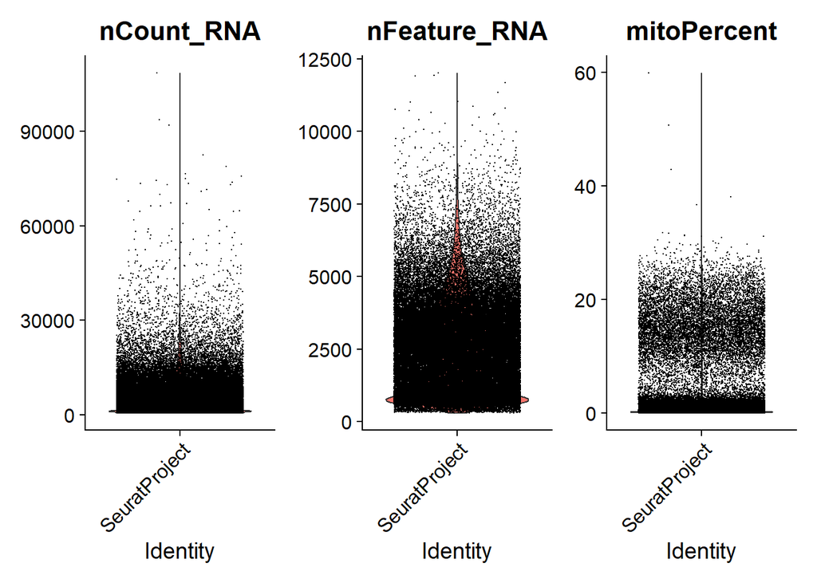

```r
# merge datasets
merged_seurat <- merge(HB17_background, y = c(HB17_PDX, HB17_tumor, HB30_PDX, HB30_tumor, HB53_background, HB53_tumor),
      add.cell.ids = ls()[3:9], # this differentiates between cells coming from different samples (i.e., patient identifier, tissue type)
      project = "HB")

# create a sample column
merged_seurat$sample <- rownames(merged_seurat@meta.data)

# split the sample column
merged_seurat@meta.data <- separate(merged_seurat@meta.data, col = 'sample', into = c('Patient', 'Type', 'Barcode'),
         sep = '_')

# calculate percent mitochondrial genes
merged_seurat$mitoPercent <-  PercentageFeatureSet(merged_seurat, pattern = "^MT-")

# look at counts, feature and mitochondrial data
VlnPlot(merged_seurat, features = c("nCount_RNA", "nFeature_RNA", "mitoPercent"), ncol = 3)
```

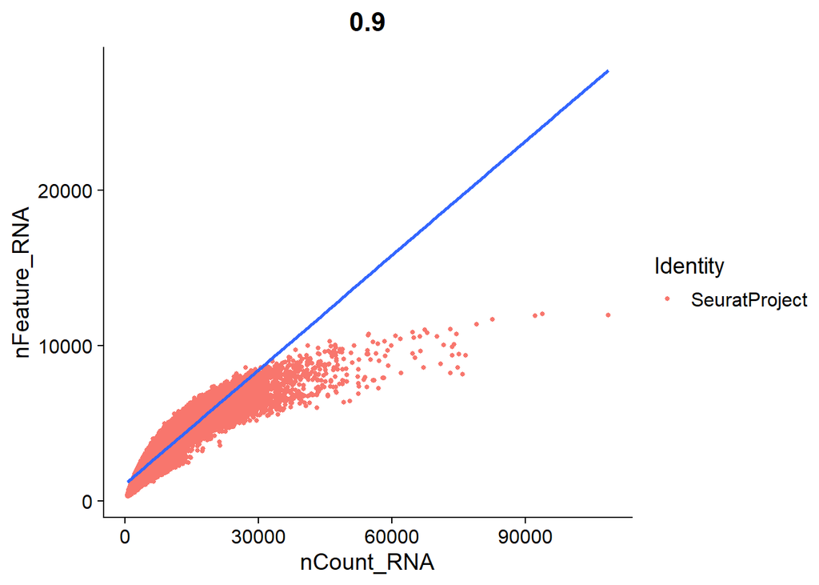

```r
# plot nCount and nFeature
FeatureScatter(merged_seurat, feature1 = "nCount_RNA", feature2 = "nFeature_RNA") +
  geom_smooth(method = 'lm')
```

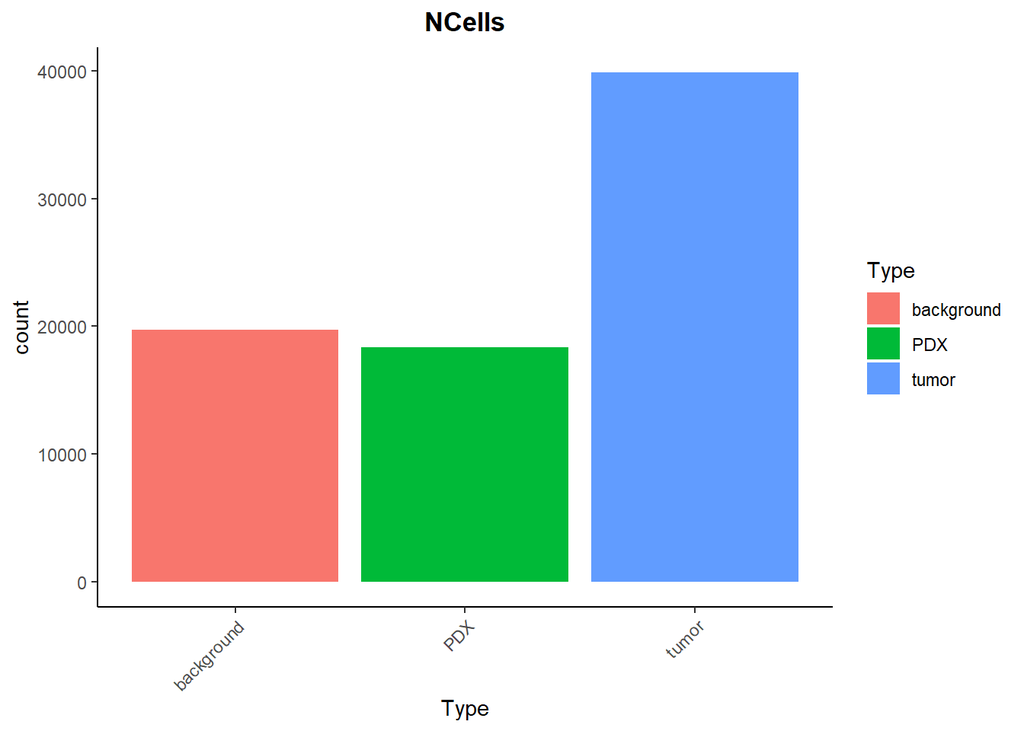

```r
# Add number of genes per UMI for each cell to metadata
merged_seurat$log10GenesPerUMI <- log10(merged_seurat$nFeature_RNA) / log10(merged_seurat$nCount_RNA)

# create metadata df
metadata <- merged_seurat@meta.data

# rename cols
metadata <- metadata %>%
  dplyr::rename(seq_folder = orig.ident,
                nUMI = nCount_RNA,
                nGene = nFeature_RNA)

# add metadata back to Seurat obj
merged_seurat@meta.data <- metadata

# Visualize the number of cell counts per sample
metadata %>%
    ggplot(aes(x=Type, fill=Type)) +
    geom_bar() +
    theme_classic() +
    theme(axis.text.x = element_text(angle = 45, vjust = 1, hjust=1)) +
    theme(plot.title = element_text(hjust=0.5, face="bold")) +
    ggtitle("NCells")
```

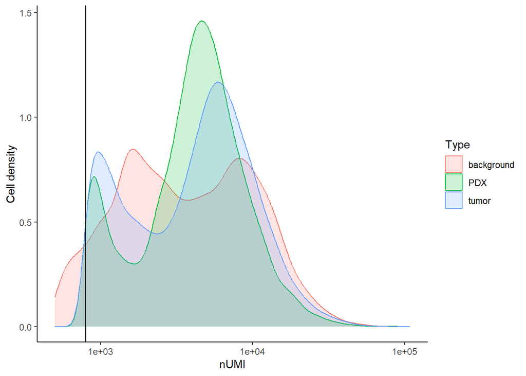

```r
# Visualize the number UMIs/transcripts per cell
metadata %>%
    ggplot(aes(color=Type, x=nUMI, fill= Type)) +
    geom_density(alpha = 0.2) +
    scale_x_log10() +
    theme_classic() +
    ylab("Cell density") +
    geom_vline(xintercept = 800)
```

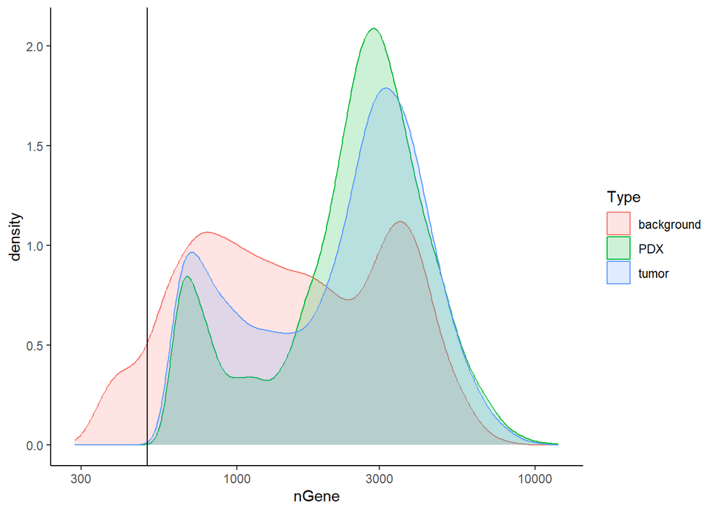

```r
# Visualize the distribution of genes detected per cell via histogram
metadata %>%
    ggplot(aes(color=Type, x=nGene, fill= Type)) +
    geom_density(alpha = 0.2) +
    theme_classic() +
    scale_x_log10() +
    geom_vline(xintercept = 500)
```

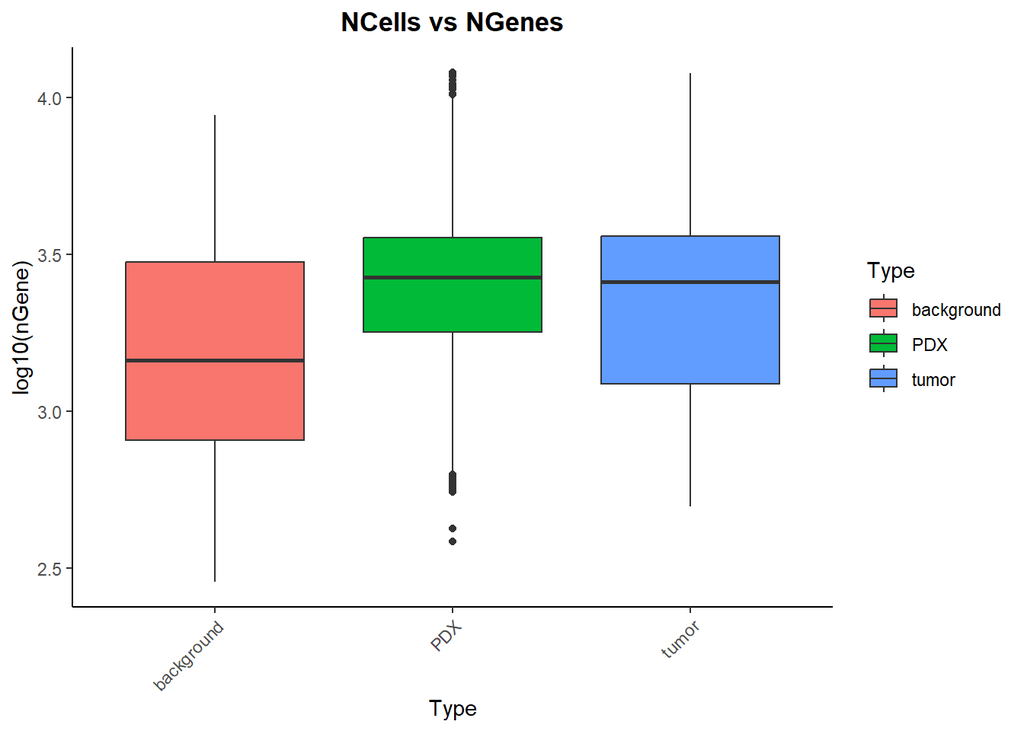

```r
# Visualize the distribution of genes detected per cell via boxplot
metadata %>%
    ggplot(aes(x=Type, y=log10(nGene), fill=Type)) +
    geom_boxplot() +
    theme_classic() +
    theme(axis.text.x = element_text(angle = 45, vjust = 1, hjust=1)) +
    theme(plot.title = element_text(hjust=0.5, face="bold")) +
    ggtitle("NCells vs NGenes")
```

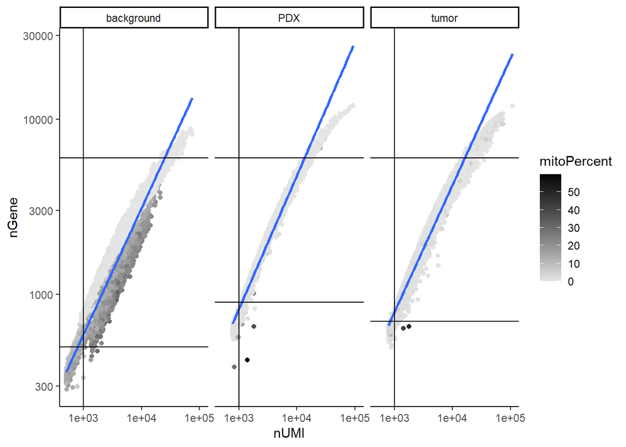

```r
# Visualize the correlation between genes detected and number of UMIs and determine whether strong presence of cells with low numbers of genes/UMIs
metadata %>%
    ggplot(aes(x=nUMI, y=nGene, color=mitoPercent)) +
    geom_point() +
  scale_colour_gradient(low = "gray90", high = "black") +
    stat_smooth(method=lm) +
    scale_x_log10() +
    scale_y_log10() +
    theme_classic() +
  facet_wrap(~Type) +
  geom_vline(xintercept = 1000) +
  geom_hline(data = filter(metadata, Type=="background"), aes(yintercept = 500)) +
  geom_hline(data = filter(metadata, Type=="background"), aes(yintercept = 6000)) +
  geom_hline(data = filter(metadata, Type=="PDX"), aes(yintercept = 6000)) +
  geom_hline(data = filter(metadata, Type=="PDX"), aes(yintercept = 900)) +
  geom_hline(data = filter(metadata, Type=="tumor"), aes(yintercept = 6000)) +
  geom_hline(data = filter(metadata, Type=="tumor"), aes(yintercept = 700))
```

From the mitochondrial percentages depicted in the final plot, it looks like PDX and tumor samples overall have a great majority of healthy cells. There are generally more samples coming from tumor tissue than the PDX and background. However, the mitochondrial percentage in the background samples is high even in cells with high UMI and gene count. However, hepatocytes in general have high mitochondrial content. Therefore, this result may not be abnormal. To account for this, I will use a more lenient threshold for mitoPercent i.e., 50%.

### Filtering

```r
# merged_seurat_study.filtered <- subset(merged_seurat, subset = nGene > 500 &
#                                          nUMI > 800 &
#                                          mitoPercent < 10)
#
# merged_seurat_study.filtered@meta.data %>%
#       ggplot(aes(x=nUMI, y=nGene, color=mitoPercent)) +
#       geom_point() +
#   scale_colour_gradient(low = "gray90", high = "black") +
#       stat_smooth(method=lm) +
#       scale_x_log10() +
#       scale_y_log10() +
#       theme_classic() +
#   facet_wrap(~Type)
```

Below, I filter using my own parameters. I decided to use quality control filters that are tissue-type specific since there are some differences between them as seen in the exploratory plots in “Quality Control” section. Specifically, the cells from background tissue show high mitoPercent.

After filtering the original merged Seurat object (cells from each type filtered separately), I visualized the number of cells retained in each Type. The proportions of the cells has not changed significantly. I also plotted the number of UMIs/number of genes correlation plot again.

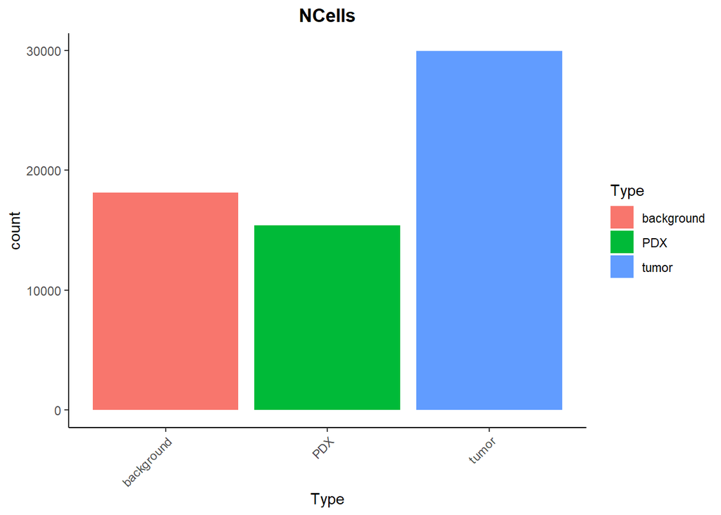

```r
# filter the cells from the different tissues separately
background <- subset(merged_seurat, subset = Type == "background" &
                       nGene > 500 & nGene < 6000 &
                       nUMI > 800 &
                       mitoPercent < 50)
pdx <- subset(merged_seurat, subset = Type == "PDX" &
                nGene > 900 & nGene < 6000 &
                nUMI > 800 &
                mitoPercent < 50)
tumor <- subset(merged_seurat, subset = Type == "tumor" &
                  nGene > 700 & nGene < 4000 &
                  nUMI > 800 &
                  mitoPercent < 50)

# merge the filtered by type seurat objects together
merged_seurat_filtered <- merge(background, y = c(pdx, tumor),
      project = "HB")

# check filtered cells to ensure filtering parameters are appropriate
metadata_filtered <- merged_seurat_filtered@meta.data

# Visualize the number of cell counts per sample
metadata_filtered %>%
    ggplot(aes(x=Type, fill=Type)) +
    geom_bar() +
    theme_classic() +
    theme(axis.text.x = element_text(angle = 45, vjust = 1, hjust=1)) +
    theme(plot.title = element_text(hjust=0.5, face="bold")) +
    ggtitle("NCells")
```

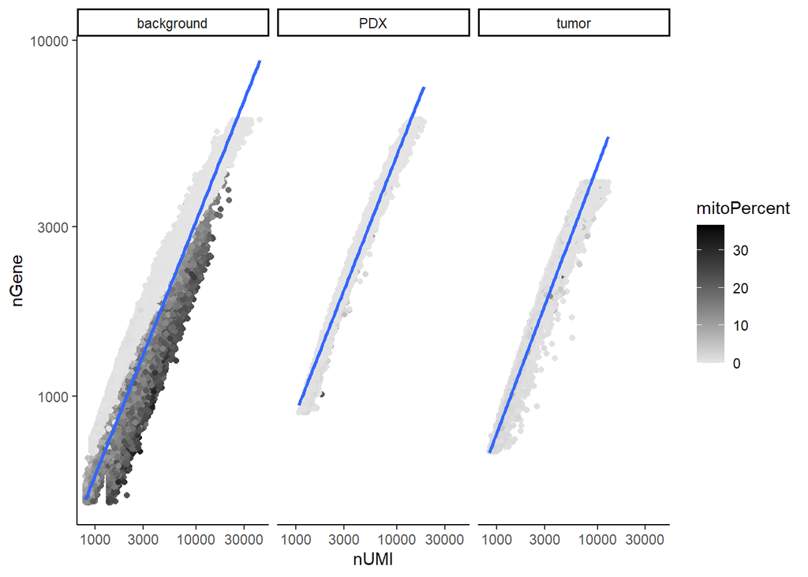

```r
# Visualize the correlation between genes detected and number of UMIs and determine whether strong presence of cells with low numbers of genes/UMIs
metadata_filtered %>%
    ggplot(aes(x=nUMI, y=nGene, color=mitoPercent)) +
    geom_point() +
  scale_colour_gradient(low = "gray90", high = "black") +
    stat_smooth(method=lm) +
    scale_x_log10() +
    scale_y_log10() +
    theme_classic() +
  facet_wrap(~Type)
```

The filtered dataset looks good. Most of the cell with high mitochondrial content are from background hepatic tissue. The proportion of number of cells in background/PDX to tumor is similar to the unfiltered dataset.

### Standard workflow

Now, I will use the filtered datasets to carry out the standard scRNA-seq analysis workflow, specifically normalizing and scaling data, and then visualizing clusters on UMAP.

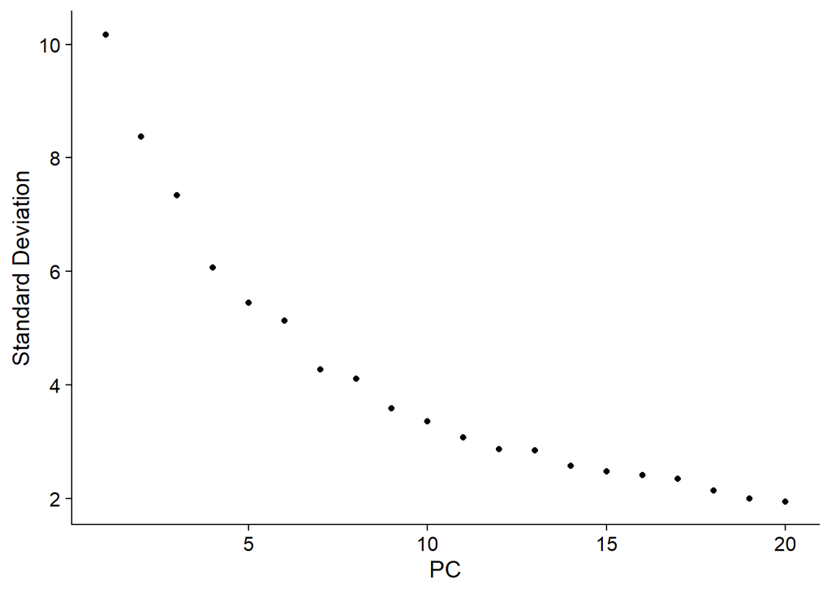

```r
merged_seurat_filtered <- NormalizeData(object = merged_seurat_filtered)
merged_seurat_filtered <- FindVariableFeatures(object = merged_seurat_filtered)
merged_seurat_filtered <- ScaleData(object = merged_seurat_filtered)
merged_seurat_filtered <- RunPCA(object = merged_seurat_filtered)
ElbowPlot(merged_seurat_filtered)
```

```r
merged_seurat_filtered <- FindNeighbors(object = merged_seurat_filtered, dims = 1:20)
merged_seurat_filtered <- FindClusters(merged_seurat_filtered)
```

```
## Modularity Optimizer version 1.3.0 by Ludo Waltman and Nees Jan van Eck
##
## Number of nodes: 63483
## Number of edges: 2275314
##
## Running Louvain algorithm...
## Maximum modularity in 10 random starts: 0.9418
## Number of communities: 38
## Elapsed time: 20 seconds
```

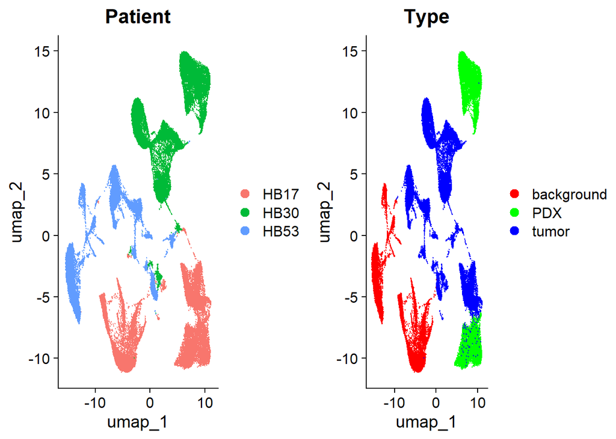

```r
merged_seurat_filtered <- RunUMAP(merged_seurat_filtered, dims = 1:20)

# plot
p1 <- DimPlot(merged_seurat_filtered, reduction = 'umap', group.by = 'Patient')
p2 <- DimPlot(merged_seurat_filtered, reduction = 'umap', group.by = 'Type', cols = c('red', 'green', 'blue'))

grid.arrange(p1, p2, ncol = 2)
```

### Data integration for batch effect correction

Since there are several integration methods for scRNA-seq data, I decided to test two methods on the dataset with my custom filter, namely canonical correlation analysis (CCA) and Harmony.

Shown first are the results of the CCA integration:

```r
seurat_integrated <- IntegrateLayers(
  object = merged_seurat_filtered, method = CCAIntegration,
  orig.reduction = "pca", new.reduction = "integrated.cca",
  verbose = FALSE
)

seurat_integrated <- FindNeighbors(seurat_integrated, reduction = "integrated.cca", dims = 1:20)
seurat_integrated <- FindClusters(seurat_integrated, resolution = 0.5, cluster.name = "cca_clusters")
```

```
## Modularity Optimizer version 1.3.0 by Ludo Waltman and Nees Jan van Eck
##
## Number of nodes: 63483
## Number of edges: 2388342
##
## Running Louvain algorithm...
## Maximum modularity in 10 random starts: 0.8936
## Number of communities: 14
## Elapsed time: 25 seconds
```

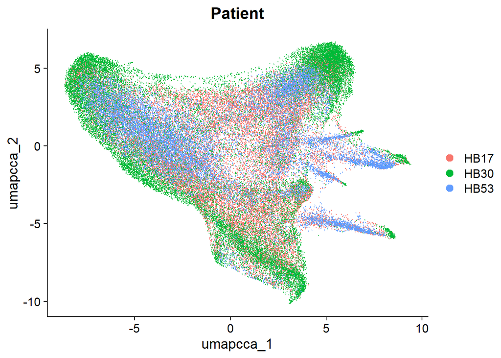

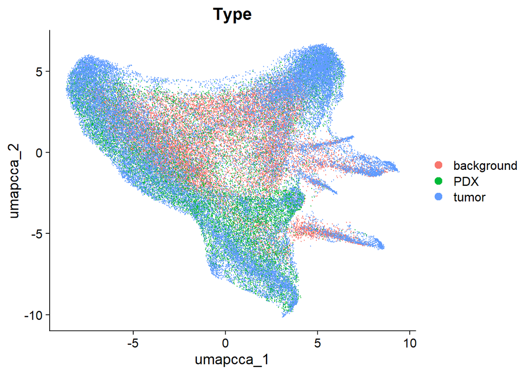

```r
seurat_integrated <- RunUMAP(seurat_integrated, reduction = "integrated.cca", dims = 1:20, reduction.name = "umap.cca")

DimPlot(
  seurat_integrated,
  reduction = "umap.cca",
  group.by = c("Patient", "Type"),
  combine = FALSE, label.size = 2)
```

Next is Harmony:

```r
harmony <- IntegrateLayers(
  object = merged_seurat_filtered, method = HarmonyIntegration,
  orig.reduction = "pca", new.reduction = "harmony",
  verbose = FALSE
)

harmony <- FindNeighbors(harmony, reduction = "harmony", dims = 1:20)
harmony <- FindClusters(harmony, resolution = 0.5, cluster.name = "harmony_clusters")
```

```
## Modularity Optimizer version 1.3.0 by Ludo Waltman and Nees Jan van Eck
##
## Number of nodes: 63483
## Number of edges: 2118098
##
## Running Louvain algorithm...
## Maximum modularity in 10 random starts: 0.9262
## Number of communities: 18
## Elapsed time: 19 seconds
```

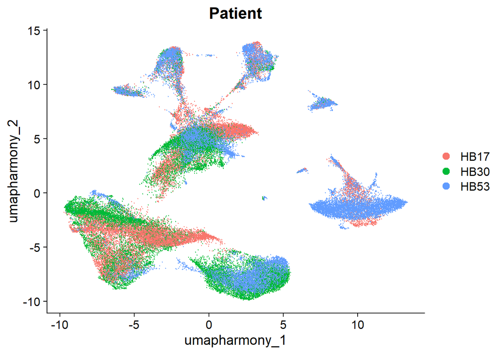

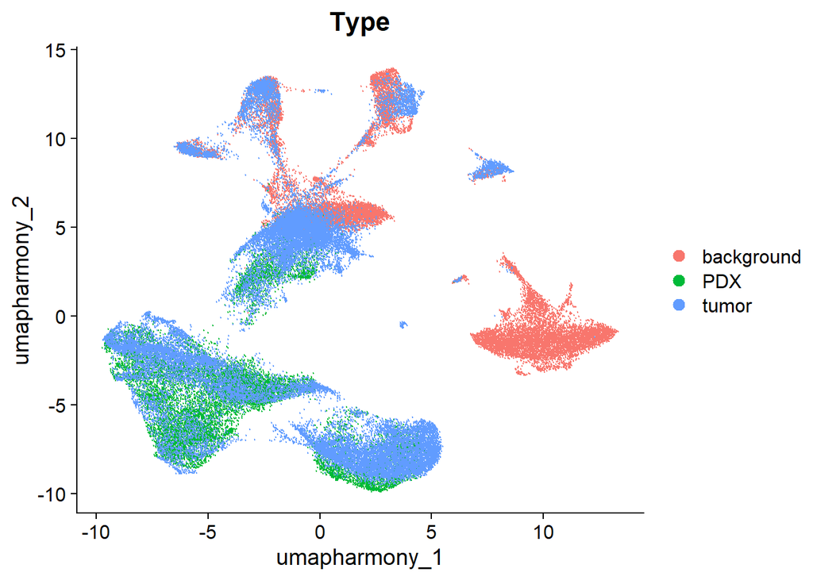

```r
harmony <- RunUMAP(harmony, reduction = "harmony", dims = 1:20, reduction.name = "umap.harmony")

DimPlot(
  harmony,
  reduction = "umap.harmony",
  group.by = c("Patient", "Type"),
  combine = FALSE, label.size = 2)
```

Therefore, I would conduct the downstream analyses with the Harmony or rPCA integrated dataset.